# Circadian Phase Estimation of Depmap Melanoma Cell Line Samples

Theo Killian

2025-04-02

# Introduction

In circadian biology, estimating the circadian phase of biological samples provides insight into the temporal regulation of gene expression. However, in many publicly available datasets, particularly large-scale cancer cell line resources like DepMap, samples are not annotated with the time of day at which they were collected, making it challenging to infer rhythmic patterns.

Despite this limitation, we may still wish to explore whether circadian rhythms persist in these in vitro systems and whether they correlate with key biological or clinical variables (e.g., primary vs. metastatic status). To do so, one might consider fitting sinusoidal models (harmonic regression) to gene expression values across samples, even in the absence of time-point annotation.

However, applying harmonic regression without known or replicated time points is inherently problematic:

```
Pseudo-time assignment (i.e., randomly assigning each sample a time point from 0–24h) introduces artificial structure, which may result in fitting noise rather than true rhythmicity.

Without temporal replicates or entrainment, any signal identified is likely a statistical artifact.
```

In this analysis, we demonstrate that:

```
Fitting a harmonic regression model using pseudo-time on melanoma cell lines from DepMap results in low R^2^ values across known circadian genes, confirming that random time assignment fits random noise.

To circumvent this, we propose an alternative strategy: projecting DepMap cell lines into the expression space of a time-annotated circadian reference dataset (GSE161566) using a nearest-centroid approach.

By comparing test samples to phase-annotated reference centroids, we can infer approximate circadian phase, even in the absence of actual time point data.
```

#### Circadian Rhythm Genes

We use the following cancer-related circadian rhythm-related genes for our analysis:

```r
known_circadian_genes <- c(
  "RORA", "PER3", "PER1", "CRY2", "RORB", "PER2", "NR1D2", "RORC", "CRY1",
  "ARNTL", "NPAS2", "CLOCK", "NR1D1", "ARNTL2")
```

#### Load Depmap sample metadata

```r
## access depmap
eh <- ExperimentHub()
query(eh, "depmap")

# get the Depmap metadata
eh[["EH7558"]] %>%
  dplyr::filter(grepl("melanoma", lineage_subtype) | ## only melanoma cell lines!
                  grepl("elanoma", Cellosaurus_NCIt_disease) |
                  grepl("elanoma", subtype_disease) |
                  grepl("elanoma", cell_line),
                !is.na(primary_or_metastasis)) %>%
  dplyr::select(-contains("issues")) %>%
  dplyr::mutate(primary_or_metastasis_binary = case_when(
    primary_or_metastasis == "Primary" ~ 0,
    primary_or_metastasis == "Metastasis" ~ 1)) %>%
  as.data.frame() -> melanoma_metadata_22Q2

rownames(melanoma_metadata_22Q2) <- melanoma_metadata_22Q2$depmap_id

saveRDS(object = melanoma_metadata_22Q2, file = "./depmap_data/melanoma_metadata_22Q2.rds")
```

```r
melanoma_metadata_22Q2 <- readRDS(file = "./depmap_data/melanoma_metadata_22Q2.rds")
```

#### Load Depmap TPM gene count data

```r
eh[["EH7556"]] %>%
  dplyr::filter(depmap_id %in% melanoma_metadata_22Q2$depmap_id) %>% ## only melanoma cell lines!
  dplyr::select(depmap_id, rna_expression, gene_name) %>%
  tidyr::pivot_wider(names_from = depmap_id,
                     values_from = rna_expression) %>%
  dplyr::filter(!duplicated(gene_name)) %>%
  tibble::column_to_rownames(var = "gene_name") %>%
  as.data.frame() -> TPM_22Q2_wide

saveRDS(object = TPM_22Q2_wide, file = "./depmap_data/TPM_22Q2_wide.rds")
```

```r
TPM_22Q2_wide <- readRDS(file = "./depmap_data/TPM_22Q2_wide.rds")

cat("Dimension before filtering:", dim(TPM_22Q2_wide), "\n")
```

```
#> Dimension before filtering: 19221 85
```

#### Filter TPM gene count data

We perform minimal filtering, to filter out genes with all-zero counts (e.g., we keep genes with total counts > 0 across all samples).

```r
keep_genes <- rowSums(TPM_22Q2_wide) > 0
filtered_data <- TPM_22Q2_wide[keep_genes, ]
cat("Dimension after filtering:", dim(filtered_data), "\n")
```

```
#> Dimension after filtering: 18969 85
```

## Visualizations

### Heatmap of Circadian Gene Expression

We’ll plot the TPM expression of circadian-related genes, to give a general impression of the variation of these genes the Depmap cell line data. We observe at first glance that there doesn’t appear to be much variation of these genes across any of the annotations. It’s possible that some of the circadian gene variation may have been removed via ComBat batch correction by the Broad Institute, but this is difficult to determine.

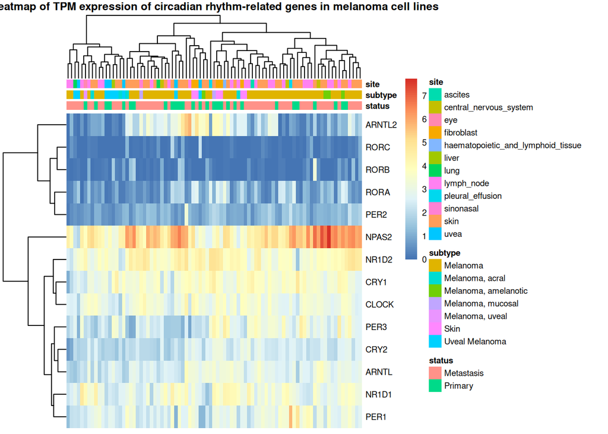

```r
filtered_data %>%
  as.data.frame() %>%
  tibble::rownames_to_column(var = "gene_name") %>%
  dplyr::filter(gene_name %in% known_circadian_genes) %>%
  tibble::column_to_rownames(var = "gene_name") %>%
  t() %>% as.data.frame() %>%
  tibble::rownames_to_column(var = "depmap_id") %>%
  dplyr::left_join(melanoma_metadata_22Q2, by = "depmap_id") %>%
  as.data.frame() -> expr_ann_df

## make column annotations
data.frame(status = expr_ann_df$primary_or_metastasis,
           subtype = expr_ann_df$subtype_disease,
           site = expr_ann_df$sample_collection_site,
           row.names = expr_ann_df$depmap_id) -> sample_col

expr_ann_df %>%
  dplyr::select(depmap_id:RORB) %>%
  tibble::column_to_rownames(var = "depmap_id") %>%
  t() %>%
  pheatmap::pheatmap(
    annotation_col = sample_col,
    show_colnames = FALSE,
    border_color = NA,
    fontsize = 7,
    main = paste0("Heatmap of TPM expression of circadian rhythm-related ",
                  "genes in melanoma cell lines"))
```

### PCA Circadian Gene Expression Matrix

Perform PCA on a bulk RNA-seq expression matrix filtered to include only circadian genes, and to visualize the result using ggplot2

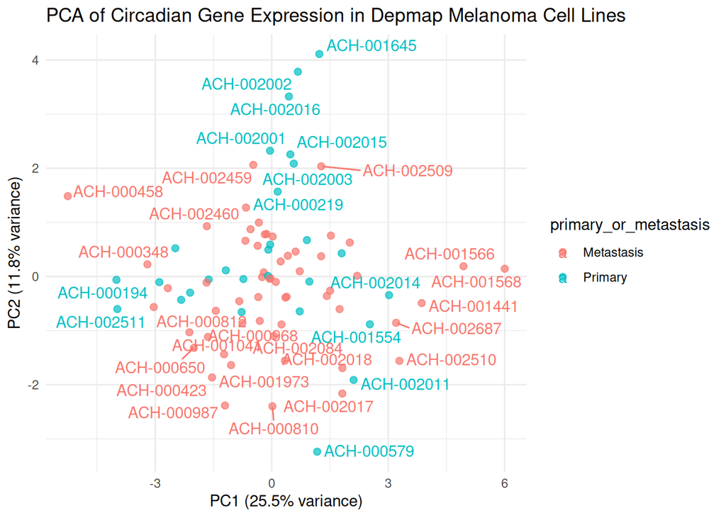

```r
filtered_data %>%
  as.data.frame() %>%
  tibble::rownames_to_column(var = "gene_name") %>%
  dplyr::filter(gene_name %in% known_circadian_genes) %>%
  tibble::column_to_rownames(var = "gene_name") %>%
  t() %>% as.data.frame() -> expr_df

# 2. Transpose for PCA (samples must be rows, genes must be columns)
# expr_for_pca <- t(expr_df)

# 3. Perform PCA (center and scale recommended for normalized data)
pca_result <- prcomp(expr_df, center = TRUE, scale. = TRUE)

# 4. Extract the PCA results for plotting
pca_df <- as.data.frame(pca_result$x)
pca_df$Sample <- rownames(pca_df)  # Keep sample names

# 5. Plot PC1 vs PC2 using ggplot2
pca_df %>%
  tibble::rownames_to_column(var = "depmap_id") %>%
  dplyr::left_join(melanoma_metadata_22Q2, by = "depmap_id") %>%
  ggplot(aes(x = PC1, y = PC2, color = primary_or_metastasis)) +
    geom_point(size = 2, alpha = 0.7) +
    geom_text_repel(aes(label = Sample)) +
    labs(title = "PCA of Circadian Gene Expression in Depmap Melanoma Cell Lines",
         x = paste0("PC1 (", round(summary(pca_result)$importance[2, 1] * 100, 1), "% variance)"),
         y = paste0("PC2 (", round(summary(pca_result)$importance[2, 2] * 100, 1), "% variance)")) +
    theme_minimal()
```

## Performing a simple harmonic regression on circadian expression data

### Define a Harmonic Regression Function

A single harmonic (period = 24h) can be modeled as:

$$y(t) = \beta_0 + \alpha \sin\left(\frac{2\pi}{24} t\right) + \gamma
\cos\left(\frac{2\pi}{24} t\right) + \varepsilon$$

You can extend it to multiple harmonics (e.g., second harmonic with period = 12h), but using the “24 hour clock” is more simple to model.

### Set Up a Pseudo-Time Vector

Since you don’t have recorded sampling times, we’ll randomly assign a pseudo-time (0–24h) for each sample. In reality, these times are made-up.

```r
# Let's assume your data frame is called 'filtered_data'
# Rows = genes, Columns = cell lines / samples.

# For demonstration, let's make it a matrix
expr_mat <- as.matrix(t(expr_df))  # e.g., TPM of circadian genes
n_samples <- ncol(expr_mat)

# Create a random pseudo-time vector from 0 to 24 (hours)
set.seed(123)  # for reproducibility
pseudo_time <- runif(n_samples, min = 0, max = 24)
```

#### Creating Regressor Columns

Regressor column equations are shown below:

Sine Regressor Term (24-hour period):

$$\text{sin}_{24}(t) = \sin\left( \frac{2\pi}{24} t \right)$$

Cosine Regressor Term (24-hour period):

$$\text{cos}_{24}(t) = \cos\left( \frac{2\pi}{24} t \right)$$
Build the design matrix for a single harmonic with period 24:

```r
omega <- 2 * pi / 24

sin_24 <- sin(omega * pseudo_time)
cos_24 <- cos(omega * pseudo_time)

# We combine them in a data frame for use in lm()
harm_design <- data.frame(
  sin_24 = sin_24,
  cos_24 = cos_24
)
```

### Fitting a Linear Model for Each Gene

We’ll write a function that:

```
Takes a vector of gene expression across samples,

Fits lm(gene_expr ~ sin_24 + cos_24, data = harm_design),

Extracts amplitude & phase from the coefficients.
```

Amplitude equation:

$$\text{amplitude} = \sqrt{\alpha^2 + \gamma^2}$$

Phase equation:

$$\text{phase} = \mathrm{atan2}(\alpha, \gamma)$$

Phase Conversion to Hours (24-hour cycle):

$$\text{phase (hours)} = \left( \frac{\text{phase (radians)}}{2\pi}
\right) \times 24$$
Create function to fit the harmonic model on the expression data:

```r
fit_harmonic <- function(y, sin_col, cos_col) {
  # y = numeric vector of expression (length = n_samples)
  # sin_col, cos_col = numeric vectors of the same length
  lmfit <- lm(y ~ sin_col + cos_col)
  coefs <- coef(lmfit)

  # coefs[1] = intercept, coefs[2] = sin coefficient, coefs[3] = cos coefficient
  alpha <- coefs[2]
  gamma <- coefs[3]

  amplitude <- sqrt(alpha^2 + gamma^2)
  # use atan2 to determine correct quadrant for phase
  phase <- atan2(alpha, gamma)  # in radians

  # We'll return a list with some stats
  return(list(
    intercept = coefs[1],
    alpha = alpha,       # sin coefficient
    gamma = gamma,       # cos coefficient
    amplitude = amplitude,
    phase_radians = phase,
    phase_hours = (phase / (2*pi)) * 24  # convert from radians to hours in a 24h cycle
  ))
}
```

### Apply This Function to Each Gene

We can loop over rows of `expr_mat`. For each gene (row), we extract the expression across samples, then fit the harmonic model using our function.

```r
# Prepare results storage
res_list <- vector("list", nrow(expr_mat))
gene_names <- rownames(expr_mat)

for (i in seq_len(nrow(expr_mat))) {
  y_i <- expr_mat[i, ]  # expression vector for gene i
  res_list[[i]] <- fit_harmonic(y_i, sin_24, cos_24)
}

# Combine results into a data frame
harm_results <- do.call(rbind, lapply(res_list, as.data.frame))
harm_results <- cbind(gene = gene_names, harm_results)
head(harm_results)
```

```
#>                gene intercept       alpha       gamma  amplitude phase_radians
#> (Intercept)    CRY1  3.400414 -0.11091157 -0.06244030 0.12727987    -2.0835456
#> (Intercept)1 ARNTL2  1.888235  0.14198757  0.38819883 0.41335070     0.3506453
#> (Intercept)2   PER3  2.679673 -0.09672018 -0.11813309 0.15267685    -2.4555294
#> (Intercept)3   RORA  1.091877 -0.04826459 -0.01411607 0.05028652    -1.8553329
#> (Intercept)4   CRY2  2.285371  0.03853432  0.05412299 0.06643939     0.6187191
#> (Intercept)5  NR1D1  3.149634 -0.02032576  0.10661057 0.10853087    -0.1883934
#>              phase_hours
#> (Intercept)   -7.9585580
#> (Intercept)1   1.3393662
#> (Intercept)2  -9.3794314
#> (Intercept)3  -7.0868498
#> (Intercept)4   2.3633328
#> (Intercept)5  -0.7196096
```

`harm_results` now has columns:

[output not shown]

`phase_radians`, `phase_hours`: estimated phase (in radians and hours)

### Inspecting the Fits

We observe:

```
Random or low amplitude for many genes = The data do not strongly fit a sinusoidal pattern.

Phase values scattered randomly = No real circadian structure.
```

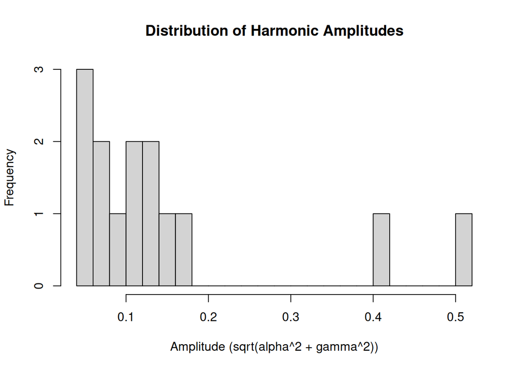

```r
hist(harm_results$amplitude, breaks = 30,
     main = "Distribution of Harmonic Amplitudes",
     xlab = "Amplitude (sqrt(alpha^2 + gamma^2))")
```

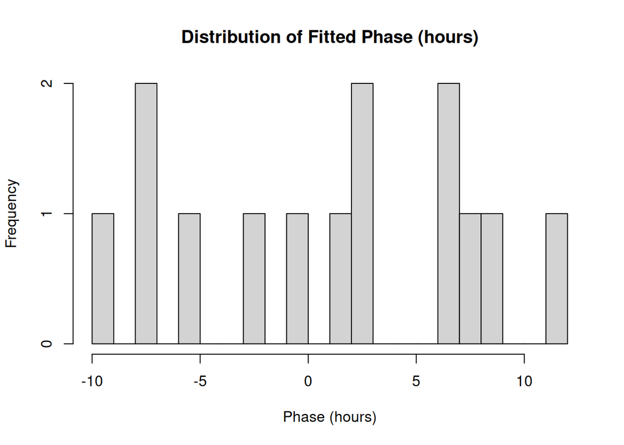

```r
hist(harm_results$phase_hours, breaks = 24,
     main = "Distribution of Fitted Phase (hours)",
     xlab = "Phase (hours)")
```

### Model Diagnostics

You can examine the R-squared of each fit to see how well (or poorly) the sinusoidal model explains the data:

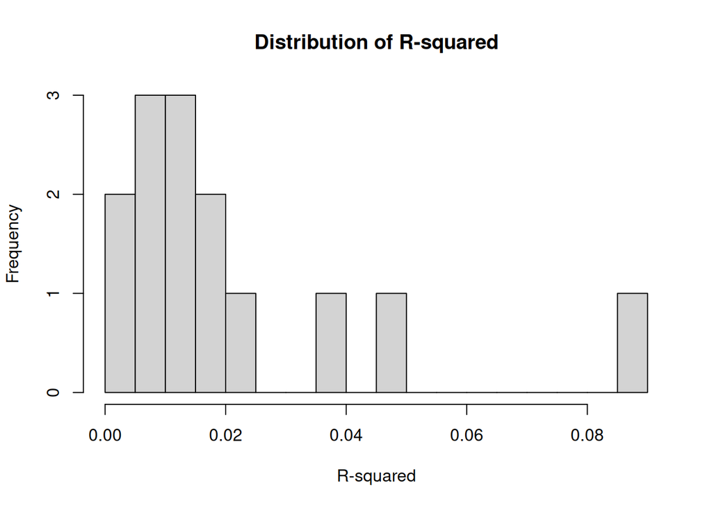

```r
get_rsq <- function(y, sin_col, cos_col) {
  m <- summary(lm(y ~ sin_col + cos_col))
  return(m$r.squared)
}

r2_values <- apply(expr_mat, 1, get_rsq, sin_col = sin_24, cos_col = cos_24)
# View(as.data.frame(r2_values))

hist(r2_values, breaks = 30, main = "Distribution of R-squared", xlab = "R-squared")
```

#### How to interpret these R<sup>2</sup> values

Low R<sup>2</sup> values across the board

```
All values are < 0.1 (i.e., < 10% of variance explained).

The highest is NPAS2 at ~0.088 (8.8%), and most are below 5%.

This strongly suggests that a sinusoidal model does not explain the variation in gene expression across your samples.
```

If the data is purely noise (and there’s no real time structure), you’d expect low R-squared across most genes.

But again, with only one measurement per sample at a random time, you’re typically just fitting noise.

Random pseudo-times lead to noise-fitting

```
Remember: you do not have actual sampling times. The time variable used in your model is random, so any apparent "fit" is just chance alignment.

Low R² values are consistent with the hypothesis that circadian structure is absent or washed out due to:

    Random sampling times.

    No temporal replicates.

    Prior batch correction (e.g., via ComBat) possibly removing subtle oscillatory signals.

    Cell lines not being entrained (a common issue in vitro).
```

The outlier (NPAS2)

```
NPAS2 has the highest R² (~0.088), but this is still too low to be considered strong.

In real circadian datasets with known time points, R² for strong clock genes like PER2, ARNTL, NR1D1 can exceed 0.5 or more.
```

#### Take-Home Message

```
The code above demonstrates how to manually build a harmonic regression for each gene using base R (lm).

Because you have no replicate time points and random sample times with no actual time data, your "phase" estimates are effectively random or noise-fitting.

This approach proves that forcing a sinusoidal model in such a setting is likely not biologically meaningful.
```

In summary: You can indeed fit a sinusoid with random time points for each sample, but the resulting amplitude/phase will not reflect true circadian patterns, rather, you’re modeling random noise.

## Building a reference circadian dataset

To overcome the limitations of applying harmonic regression to time-agnostic datasets, we leverage external, time-annotated circadian transcriptomic datasets as a reference for inferring phase. Specifically, we will utilize GSE161566, a publicly available RNA-seq dataset profiling circadian gene expression across multiple time points (24 to 70 hours) in human intestinal organoids. This dataset provides a high-resolution temporal map of rhythmic gene expression under controlled conditions. By treating each time point in the reference as a “template” of circadian phase, we can project our DepMap melanoma cell line TPM data into this reference space. This is achieved by computing correlations between the expression profiles of DepMap samples and reference time-point centroids derived from `GSE161566`. The time point with the highest similarity is interpreted as the inferred circadian phase of each cell line. This approach allows us to estimate rhythmic phase indirectly, without requiring time-stamped or replicated samples in the test data, while grounding our analysis in a biologically relevant reference system.

### CircaKB: A Comprehensive Knowledgebase of Circadian Genes Across Multiple Species

We chose the `GSE161566` dataset out of the list of Homo sapiens circadian-related datasets found on [CircaKB](https://cdsic.njau.edu.cn/CircaKB/#/home) because it is also RNAseq and also TPM transformed. While other datasets more closely resembling melanoma cell lines are available, they are microarray data, which can be difficult to compare to RNAseq. The metadata of table of circadian-related datasets available on CircaKB is shown below:

```r
readxl::read_excel(path = "./data/circakb_geo_homo_sapien_circadian_datasets.xlsx") %>%
  as.data.frame() -> circakb_geo_homo_sapien_circadian_datasets

DT::datatable(circakb_geo_homo_sapien_circadian_datasets)
```

|  | Title | Organism | Tissue | Condition | Experimental_Strategy | Timepoints | Size | Accession_ID | Online_Browse |
| --- | --- | --- | --- | --- | --- | --- | --- | --- | --- |
| 1 | High temporal resolution profiling of U2OS fibroblasts | H. sapiens | U2OS fibroblasts (osteosarcoma) | Other | Gene microarray | 24,25,26,27,28,29,30,31,32,33,34,35,36,37,38,39,40,41,42,43,44,45,46,47,48,49,50,51,52,53,54,55,56,57,58,59,60,61,62,63,64,65,66,67,68,69,70,71 | 48 | GSE13949 | Circadian Oscillation |
| 2 | Non-circadian expression masking clock-driven weak transcription rhythms in U2OS cells | H. sapiens | U2OS cells (bone-epithelial) | Other | Gene microarray | 24,27,30,33,36,39,42,45,48,51,54,57,60,63,66,69 | 32 | GSE57891 | Circadian Oscillation |
| 3 | Blood gene expression reveals reduced circadian rhythmicity in individuals resistant to sleep deprivation | H. sapiens | Blood | Sleep | Gene microarray | \ | 249 | GSE56931 | \ |
| 4 | (Baseline) Resitant Vs. Sensitive | H. sapiens | Blood | Sleep | Gene microarray | 8,12,16,20,24,28,32,36,40,44 | 40 | GSE56931 | Differential Rhythmicity |
| 5 | (Sleepdep) Resitant Vs. Sensitive | H. sapiens | Blood | Sleep | Gene microarray | 0,4,8,12,16,20 | 60 | GSE56931 | Differential Rhythmicity |
| 6 | (Resitant) Baseline Vs. Sleepdep | H. sapiens | Blood | Sleep | Gene microarray | 0,4,8,12,16,20 | 24 | GSE56931 | Differential Rhythmicity |
| 7 | (Sensitive) Baseline Vs. Sleepdep | H. sapiens | Blood | Sleep | Gene microarray | 0,4,8,12,16,20 | 48 | GSE56931 | Differential Rhythmicity |
| 8 | The effects of aging on circadian patterns of gene expression in the human prefrontal cortex | H. sapiens | Prefrontal cortex | Aging | Gene microarray | \ | 420 | GSE71620 | \ |
| 9 | BA47 | H. sapiens | Prefrontal cortex | Aging | Gene microarray | ZT18.17,ZT18.39,ZT18.43,ZT18.53,ZT18.58,ZT19.09,ZT19.79,ZT19.89,ZT20.12,ZT20.62,ZT21.17,ZT21.2,ZT22.85,ZT24.7,ZT25.37,ZT26.23,ZT26.24,ZT26.87,ZT26.91,ZT27.93,ZT28.03,ZT28.08,ZT28.45,ZT28.91,ZT29.35,ZT… | 146 | GSE71620 | Circadian Oscillation |
| 10 | BA11 | H. sapiens | Prefrontal cortex | Aging | Gene microarray | ZT18.17,ZT18.39,ZT18.43,ZT18.53,ZT18.58,ZT19.09,ZT19.79,ZT19.89,ZT20.12,ZT20.62,ZT21.17,ZT21.2,ZT22.85,ZT24.7,ZT25.37,ZT26.23,ZT26.24,ZT26.87,ZT26.91,ZT27.93,ZT28.03,ZT28.08,ZT28.45,ZT28.91,ZT29.35,ZT… | 146 | GSE71620 | Circadian Oscillation |

[output cut: 28 more lines]

Load the GEO GSE161566 data:

```r
## annotation metadata?
# readxl::read_excel("./GEO_data/GSE161566_Human-enteroids_RAIN-24h_EMBO.xlsx") %>%
#   dplyr::mutate(gene_symbol = gsub(".*?:", "", CycID)) %>%
#   dplyr::filter(gene_symbol %in% known_circadian_genes) %>%
#   dplyr::select(gene_symbol, everything()) %>%
#   as.data.frame() -> GSE161566_Human_enteroids_RAIN_24h_EMBO
# View(GSE161566_Human_enteroids_RAIN_24h_EMBO)

readr::read_csv("./GEO_data/GSE161566_processed-data-file_TPM.csv") %>%
  dplyr::rename(gene_symbol = Symbol) %>%
  dplyr::filter(gene_symbol %in% known_circadian_genes) %>%
  dplyr::select(-Ensembl) %>%
  tibble::column_to_rownames(var = "gene_symbol") %>%
  as.data.frame() -> GSE161566_processed_data_file_TPM
# View(GSE161566_processed_data_file_TPM)
```

### PCA of time-annotated GSE161566 data colored by 24-hour phase

We plot the PCA of the time-annotated GSE161566 data, and convert the time annotation to the 24-hour phase. We observe that there does appear to be a temporal expression pattern in circadian genes in this dataset.

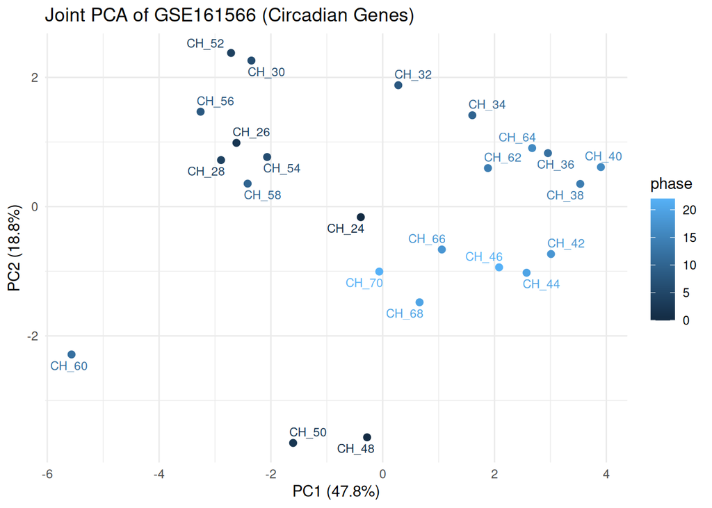

```r
# Transpose: rows = samples, cols = genes
pca_res <- prcomp(t(GSE161566_processed_data_file_TPM), center=TRUE, scale.=TRUE)

as.data.frame(pca_res$x) %>%
  tibble::rownames_to_column("sample_id") %>%
  dplyr::mutate(phase = as.integer(gsub(".*?_", "", sample_id)) %% 24) %>%
  ggplot(aes(x = PC1, y = PC2, color = phase)) +
    geom_point(size = 2) +
    geom_text_repel(aes(label = sample_id), size = 3, force = TRUE) +
    theme_minimal() +
    labs(title="Joint PCA of GSE161566 (Circadian Genes)",
         x=paste0("PC1 (", round(summary(pca_res)$importance[2,1]*100,1), "%)"),
         y=paste0("PC2 (", round(summary(pca_res)$importance[2,2]*100,1), "%)"))
```

Explanation of Key Steps:

```
Load Reference Data (GSE161566):

    Already in TPM, so no need for further count-to-TPM conversion.

    Extract numeric time points from sample IDs like "CH_24" → time_point = 24.

Annotate & Melt:

    We reshape the data so each row is (sample, gene, expression) and join with the time_point.

Build Centroid Matrix:

    We group by (time_point, gene) and take the average expression.

    In GSE161566 with 1 replicate per time point, the centroid is effectively the sample itself.

Load Test (Cell Line) Data:

    Already presumably in TPM or similar normalized values.

    Subset to common genes.

Nearest-Centroid Phase Inference:

    For each test sample, correlate its expression vector to each reference time point’s expression vector.

    The reference time point with the highest correlation is assigned as the "predicted phase."

(Optional) Joint PCA:

    Combine the reference "samples" (the time points) with the test cell lines in one matrix.

    Transpose so rows = samples, columns = genes.

    Perform prcomp to visualize how cell lines cluster relative to the reference circadian cycle.
```

### Circadian phase estimates of Depmap using time-annotated GSE161566 data

```r
################################################################################
# 1) REFERENCE DATA (GSE161566) -- TPM with column names like "CH_24","CH_26", etc.
################################################################################

# "GSE161566_processed_data_file_TPM" is assumed loaded:
#   rows = genes, columns = samples, values = TPM

# Let's check dimension:
# cat("Reference data dimensions:", dim(GSE161566_processed_data_file_TPM), "\n")
# cat("Sample of colnames:\n")
# head(colnames(GSE161566_processed_data_file_TPM))

# Extract numeric time points from column names, e.g. "CH_24" => 24
# We'll create a named vector of time points
extract_time_from_name <- function(col_name) {
  # Suppose the format is "CH_XX" or "CH_XXX"
  # We'll remove "CH_" and convert what's left to numeric
  as.numeric(sub("CH_", "", col_name))
}

ref_colnames <- colnames(GSE161566_processed_data_file_TPM)
time_points <- sapply(ref_colnames, extract_time_from_name)

# We'll store this in a small metadata frame
reference_meta <- data.frame(
  sample_id = ref_colnames,
  time_point = time_points,
  stringsAsFactors = FALSE
)

# OPTIONAL: if you have a reason to do a small offset or reorder, do it here

################################################################################
# 2) ANNOTATE REFERENCE DATA WITH TIME AND MELT TO LONG FORMAT
################################################################################

# Transpose so each row = sample, each column = gene
ref_data_t <- t(GSE161566_processed_data_file_TPM)

# Build a data frame with time_point
as.data.frame(ref_data_t) %>%
  tibble::rownames_to_column("sample_id") %>%
  dplyr::left_join(reference_meta, by = "sample_id") %>%
  as.data.frame() -> ref_combined_df # join the time_point info

# Now we have columns = genes, plus sample_id, time_point

# Convert to long format
ref_combined_df %>%
  tidyr::gather(key = "gene", value = "expression", -sample_id, -time_point) %>%
  as.data.frame() -> ref_long

################################################################################
# 3) CREATE TIME-POINT "CENTROIDS" (In this dataset, 1 replicate/time => trivial)
################################################################################

ref_long %>%
  dplyr::group_by(time_point, gene) %>%
  dplyr::summarize(mean_expr = mean(expression, na.rm = TRUE)) %>%
  dplyr::ungroup() %>%
  as.data.frame() -> ref_time_centroids

# Convert back to wide format: rows = time_point, columns = genes
ref_time_centroids %>%
  tidyr::spread(key = gene, value = mean_expr) %>%
  as.data.frame() -> ref_time_wide

time_centroid_matrix <- as.matrix(ref_time_wide[, -1])
rownames(time_centroid_matrix) <- ref_time_wide$time_point

# cat("Dimensions of time_centroid_matrix:", dim(time_centroid_matrix), "\n")
# head(rownames(time_centroid_matrix))

################################################################################
# 4) LOAD THE CELL LINE (TEST) EXPRESSION DATA (expr_matx)
################################################################################

# Suppose your cell line data frame is called "expr_matx" in TPM
# with rows = genes, columns = cell lines. If it's already in memory, proceed:
# e.g. expr_matx <- read.csv("my_cell_lines.csv", row.names=1)

# cat("Dimensions of cell line data (expr_matx):", dim(expr_mat), "\n")
# cat("Column names in expr_mat:\n")
# head(colnames(expr_mat))

# Ensure it's a matrix
test_expr <- as.matrix(expr_mat)

################################################################################
# 5) OPTIONAL: SUBSET TO COMMON GENES
################################################################################

common_genes <- intersect(colnames(time_centroid_matrix), rownames(test_expr))

# cat("Number of overlapping circadian genes:", length(common_genes), "\n")

ref_sub  <- time_centroid_matrix[, common_genes, drop=FALSE]
test_sub <- test_expr[common_genes, , drop=FALSE]

################################################################################
# 6) INFER CIRCADIAN PHASE BY NEAREST-CENTROID CORRELATION
################################################################################

predict_circadian_phase <- function(sample_vector, ref_centroids) {
  # ref_centroids: rows = time_points, cols = genes
  # sample_vector: expression of the same genes in the test sample
  cor_values <- apply(ref_centroids, 1, function(x) cor(x, sample_vector, use="pairwise.complete.obs"))
  best_time  <- names(which.max(cor_values))
  return(best_time)
}

test_samples <- colnames(test_sub)
phase_estimates <- sapply(test_samples, function(samp) {
  sample_vec <- test_sub[, samp]
  predict_circadian_phase(sample_vec, ref_sub)
})

cat("Predicted circadian time for each cell line sample:\n")
```

```
#> Predicted circadian time for each cell line sample:
```

```r
print(phase_estimates)
```

```
#> ACH-001339 ACH-000765 ACH-000465 ACH-000550 ACH-002687 ACH-000194 ACH-000322
#>       "24"       "30"       "24"       "24"       "52"       "30"       "34"
#> ACH-002508 ACH-000632 ACH-000240 ACH-000135 ACH-000441 ACH-000805 ACH-001554
#>       "24"       "26"       "46"       "30"       "28"       "28"       "52"
#> ACH-000580 ACH-001441 ACH-001568 ACH-002847 ACH-002458 ACH-001569 ACH-001973
#>       "26"       "26"       "46"       "34"       "26"       "24"       "24"
#> ACH-002018 ACH-002003 ACH-002461 ACH-001041 ACH-000799 ACH-002511 ACH-002017
#>       "38"       "46"       "24"       "38"       "38"       "30"       "34"
#> ACH-002460 ACH-000614 ACH-000014 ACH-000348 ACH-000043 ACH-001566 ACH-000572
#>       "26"       "38"       "24"       "26"       "40"       "26"       "26"
#> ACH-001239 ACH-001970 ACH-000275 ACH-000404 ACH-000882 ACH-000458 ACH-002084
#>       "34"       "26"       "30"       "38"       "34"       "46"       "24"
#> ACH-001522 ACH-000650 ACH-001563 ACH-002510 ACH-000822 ACH-000812 ACH-002509
#>       "46"       "34"       "40"       "48"       "26"       "30"       "26"
#> ACH-001982 ACH-000730 ACH-001567 ACH-001190 ACH-002459 ACH-001645 ACH-000304
#>       "34"       "34"       "46"       "52"       "26"       "26"       "30"
#> ACH-000931 ACH-000810 ACH-002001 ACH-000450 ACH-000423 ACH-000915 ACH-000881
#>       "40"       "30"       "26"       "46"       "26"       "30"       "34"
#> ACH-000899 ACH-000306 ACH-000884 ACH-002926 ACH-000477 ACH-002016 ACH-000401
#>       "38"       "30"       "38"       "24"       "34"       "52"       "26"
#> ACH-002015 ACH-002512 ACH-000987 ACH-000644 ACH-000219 ACH-002014 ACH-000582
#>       "24"       "26"       "34"       "24"       "38"       "26"       "26"
#> ACH-001570 ACH-000640 ACH-002002 ACH-002011 ACH-000579 ACH-000788 ACH-000968
#>       "26"       "52"       "46"       "34"       "28"       "34"       "26"
#> ACH-000750
#>       "40"
```

The predicted circadian phases for the DepMap melanoma cell lines, estimated by correlating each sample to reference time points in GSE161566 are predominantly clustered around a narrow subset of time points, particularly “24”, “26”, “30”, and “34”, with a small tail extending to later time points like “46”, “52”, and “48”. This distribution suggests limited diversity in circadian phase among the cell lines, consistent with the expectation that in vitro melanoma cell lines lack entrainment and do not exhibit strong circadian oscillations. The non-uniform spread also indicates that the nearest-centroid inference may be driven by other dominant transcriptional features (e.g., baseline expression similarities), rather than true phase differences.

### Distribution of Predicted Circadian Phases

We plot the predicted circadian time for each Depmap cell line:

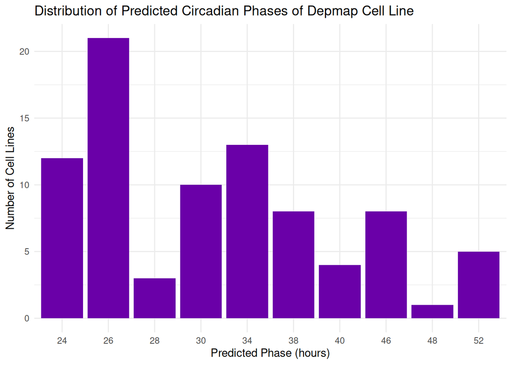

```r
# Convert phase estimates to a data frame
phase_df <- data.frame(
  depmap_id = names(phase_estimates),
  predicted_phase = as.numeric(phase_estimates)
)

# Bar plot
ggplot(phase_df, aes(x = factor(predicted_phase, levels = sort(unique(predicted_phase))))) +
  geom_bar(fill = "#6A00A8FF") +
  theme_minimal() +
  labs(
    title = "Distribution of Predicted Circadian Phases of Depmap Cell Line",
    x = "Predicted Phase (hours)",
    y = "Number of Cell Lines"
  )
```

### Distribution of Predicted Circadian Phases (Circular, 24-hour cycle)

We plot the predicted circadian time for each Depmap cell line using a circular, 24-hour cycle:

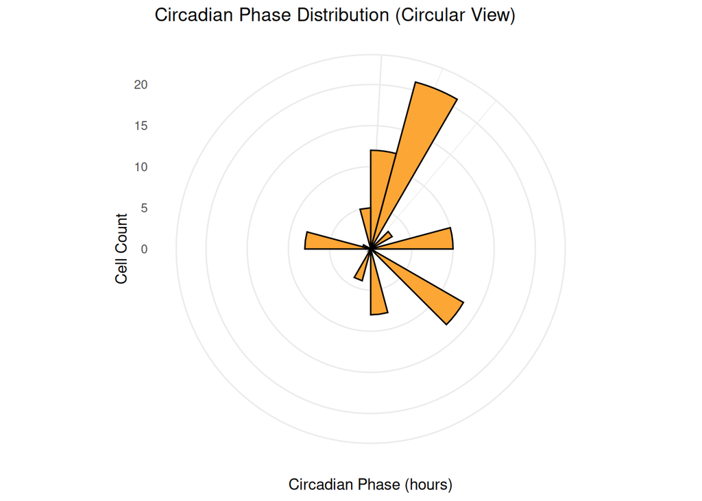

```r
# Normalize phase into radians for circular layout
phase_df$angle <- (as.numeric(phase_df$predicted_phase) / 24) * 2 * pi

ggplot(phase_df, aes(x = angle)) +
  geom_histogram(bins = 24, fill = "#FCA636FF", color = "black") +
  coord_polar(start = 0) +
  theme_minimal() +
  scale_x_continuous(
    breaks = seq(0, 2*pi, length.out = 9),
    labels = seq(0, 24, by = 3)
  ) +
  labs(
    title = "Circadian Phase Distribution (Circular View)",
    x = "Circadian Phase (hours)",
    y = "Cell Count"
  )
```

### Joint PCA of Depmap and time-annotated GSE161566 data

```r
################################################################################
# 7) (OPTIONAL) PERFORM A JOINT PCA WITH REFERENCE + TEST SAMPLES
################################################################################
# You may or may not want to do batch correction. We'll omit that for simplicity.

# Combine ref + test in a single matrix.
# For reference "samples" = time points in time_centroid_matrix
#   => Actually, we have time_centroid_matrix as rows=timepoints, columns=genes
# We need to transpose it back if we want each column as a "sample"

# But if your reference had multiple replicates/time, you might store them differently.
# Here, let's do a simpler approach: treat each time point in GSE161566 as one "sample."

# We'll call the reference samples "REF_CH_XX"
ref_sample_names <- paste0("REF_CH_", rownames(ref_sub))
ref_for_pca <- t(ref_sub)  # Now rows=genes, columns=time_points => we want genes x timepoints
colnames(ref_for_pca) <- ref_sample_names

# The test data is genes x cell lines
test_for_pca <- test_sub  # genes x samples
# cat("Reference for PCA:", dim(ref_for_pca), "\n")
# cat("Test for PCA:", dim(test_for_pca), "\n")

# Combine (by columns) if row ordering matches (should be genes in rows)
# Ensure rownames are identical in same order
identical(rownames(ref_for_pca), rownames(test_for_pca))  # Should be TRUE if we did everything right
```

```
#> [1] TRUE
```

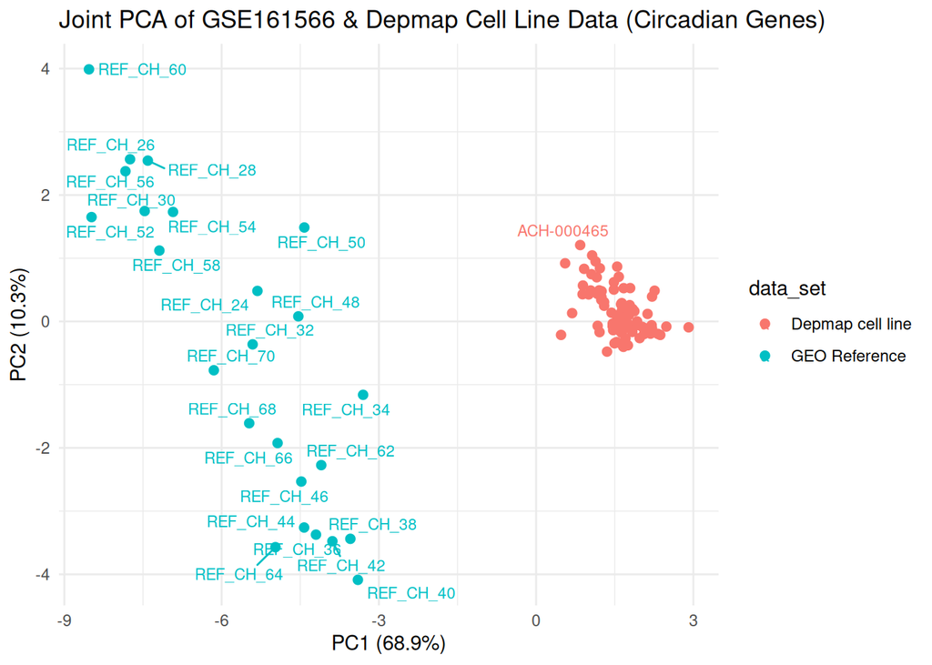

```r
joint_expr <- cbind(ref_for_pca, test_for_pca)

# Transpose: rows = samples, cols = genes
pca_res <- prcomp(t(joint_expr), center=TRUE, scale.=TRUE)

as.data.frame(pca_res$x) %>%
  tibble::rownames_to_column("sample_id") %>%
  dplyr::mutate(data_set = ifelse(
    grepl("^REF_CH_", sample_id), "GEO Reference", "Depmap cell line")) %>%
  ggplot(aes(x = PC1, y = PC2, color = data_set)) +
    geom_point(size = 2) +
    geom_text_repel(aes(label = sample_id), size = 3, force = TRUE) +
    theme_minimal() +
    labs(title="Joint PCA of GSE161566 & Depmap Cell Line Data (Circadian Genes)",
         x=paste0("PC1 (", round(summary(pca_res)$importance[2,1]*100,1), "%)"),
         y=paste0("PC2 (", round(summary(pca_res)$importance[2,2]*100,1), "%)"))
```

#### Interpretation of PCA

[output not shown]

#### Key Takeaways

```
This PCA result supports the validity of the GSE161566 dataset as a circadian reference: it encodes temporal information visibly.

It also confirms the absence of synchronized circadian structure in DepMap melanoma cell lines, aligning with expectations for in vitro systems not subjected to entrainment cues (e.g., light-dark cycles, serum shocks).

This justifies the use of nearest-centroid phase inference rather than harmonic regression on the test set, and cautions against overinterpreting phase estimates from unsynchronized bulk data.
```